# Quantum Dynamics in a Magnetic Field: Ground State, Currents, and Time Evolution

This notebook models a two-component (spin-1/2) Bose-Einstein Condensate or quantum particle in a 2D space subjected to an external magnetic field, an electric field, and a confining potential well.

The Hamiltonian of the system includes the kinetic term with minimal coupling, a non-linear Gross-Pitaevskii (GP) interaction, Zeeman spin splitting, and a confining potential:

$$H = \frac{1}{2m}(\vec{p} - q\vec{A})^2 + V_{trap}(\vec{r}) + g|\psi|^2 - \frac{\hbar q B}{2m}\sigma_z + q A_t$$

We will calculate the ground state using **Imaginary Time Evolution**, analyze the **Probability and Spin Currents**, and perform a **Real-Time Evolution** using a Runge-Kutta 4th order (RK4) solver.

```python
import numpy as np
import matplotlib.pyplot as plt
import matplotlib.animation as animation

# --- GLOBAL PLOT SETTINGS (Publication Quality) ---
plt.rcParams.update({
    "text.usetex": True,
    "font.family": "serif",
    "font.serif": ["Computer Modern"],
    "font.size": 11,
    "axes.labelsize": 11,
    "xtick.labelsize": 10,
    "ytick.labelsize": 10,
    "legend.fontsize": 10,
    "figure.titlesize": 12,
})
```

## 1. System Setup and Grid Discretization

We define the 2D spatial grid and the corresponding momentum grid using Fast Fourier Transforms (FFT). We also initialize a trial wave function (a Gaussian wave packet in the spin-up component).

```python
# Spatial Grid definition
Lx, Ly = 5, 5
N = 128
x = np.linspace(-Lx, Lx, N, endpoint=False)
y = np.linspace(-Ly, Ly, N, endpoint=False)
X, Y = np.meshgrid(x, y)
dx = x[1] - x[0]
dy = y[1] - y[0]

# Momentum Grid definition (for FFT derivatives)
kx = np.fft.fftfreq(N, d=dx) * 2 * np.pi
ky = np.fft.fftfreq(N, d=dy) * 2 * np.pi
KX, KY = np.meshgrid(kx, ky)

def normalize(psi):
    """Normalizes the 2-component spinor wave function."""
    norm = np.sqrt(np.sum(np.abs(psi)**2) * dx * dy)
    return psi / norm

# Initial trial wave function (Gaussian in spin-up)
sigma = 2.5
psi = np.zeros((2, N, N), dtype=complex)
psi[0, :, :] = np.exp(-(X**2) / (2 * sigma**2)) # Spin UP
psi[1, :, :] = np.zeros_like(X)                 # Spin DOWN
psi = normalize(psi)
```

## 2. Gauge Fields and Potentials

We apply a uniform magnetic field $B$ using the Landau gauge $\vec{A} = (0, Bx)$ and an electric field via the scalar potential $A_t = Ex$. We also define a confining well potential in the $x$-direction to prevent boundary issues with the periodic conditions assumed by the FFT.

```python
# Physical Parameters
g = 0     # Gross-Pitaevskii interaction strength
B = 1     # Magnetic field
E = 0.5   # Electric field
q = 1     # Charge
m = 1     # Mass
hbar = 1  # Reduced Planck constant

# Gauge formulation: A = (A_x, A_y), Scalar potential = A_t
A_x = np.zeros_like(psi)
A_y = np.zeros_like(psi)
A_y[0, :, :] = B * X
A_y[1, :, :] = B * X

A_t = np.zeros_like(psi)
A_t[0, :, :] = E * X
A_t[1, :, :] = E * X

# Confining potential well
omega_B = q * B / m
V_0 = 9 * hbar * omega_B
x_max = Lx / 1.5
potential_well = V_0 * (1 + np.tanh((np.abs(X) - 0.75 * x_max) * 9))
```

## 3. Hamiltonian Operators

Using spectral derivatives via FFT, we construct the operators for the Hamiltonian. FFT is highly accurate for smooth periodic functions and avoids the numerical dissipation of finite differences.

```python
def calc_gp_potential(psi, g):
    """Non-linear Gross-Pitaevskii potential term."""
    density = np.sum(np.abs(psi)**2, axis=0)
    return g * density

def kinetic_hamiltonian(psi, A_x, A_y, A_t, KX, KY, hbar=1, m=1, q=1):
    """Applies minimal coupling kinetic Hamiltonian using spectral derivatives."""
    psi_k = np.fft.fft2(psi, axes=(1, 2))

    # Spectral derivatives
    d_psi_x = np.fft.ifft2(1j * KX * psi_k, axes=(1, 2))
    d_psi_y = np.fft.ifft2(1j * KY * psi_k, axes=(1, 2))
    laplacian = np.fft.ifft2(-(KX**2 + KY**2) * psi_k, axes=(1, 2))

    A_dot_grad = A_x * d_psi_x + A_y * d_psi_y
    A_sq = A_x**2 + A_y**2

    term1 = -(hbar**2 / (2 * m)) * laplacian
    term2 = 1j * (hbar * q / m) * A_dot_grad
    term3 = (q**2 / (2 * m)) * A_sq * psi
    term4 = q * A_t * psi

    return term1 + term2 + term3 + term4

def spin_hamiltonian(psi, B, hbar=1, m=1, q=1):
    """Zeeman spin splitting."""
    omega_B = q * B / m
    E_spin = np.zeros_like(psi)
    E_spin[0, :, :] = -hbar * omega_B / 2 * psi[0, :, :]
    E_spin[1, :, :] = hbar * omega_B / 2 * psi[1, :, :]
    return E_spin
```

## 4. Ground State via Imaginary Time Evolution

We find the ground state by evolving the system in imaginary time $\tau = it$. High energy modes decay exponentially faster, ensuring convergence to the ground state.

$$\psi(\tau + \Delta\tau) \approx (1 - H\Delta\tau)\psi(\tau)$$

```
Starting imaginary time evolution...
Convergence reached at step 8400! Energy = -0.112857
```

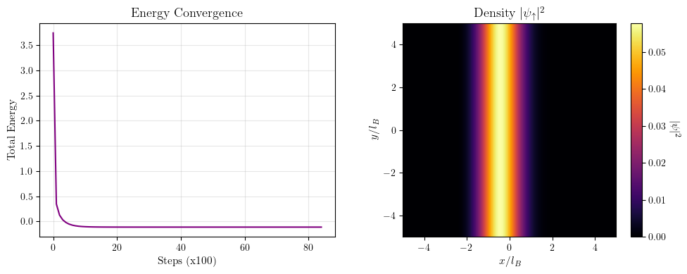

```python
dtau = 0.001
max_steps = 20000
energy_tolerance = 1e-10
energies = []

print("Starting imaginary time evolution...")

for step in range(max_steps):
    H_kin = kinetic_hamiltonian(psi, A_x, A_y, A_t, KX, KY)
    H_gp  = calc_gp_potential(psi, g) * psi
    H_sp  = spin_hamiltonian(psi, B)
    H_trap = potential_well * psi

    H_total = H_kin + H_gp + H_sp + H_trap

    # Forward Euler step in imaginary time
    psi_new = psi - H_total * dtau
    psi = normalize(psi_new)

    # Check convergence periodically
    if step % 100 == 0:
        expected_energy = np.sum(np.conj(psi) * H_total).real * dx * dy
        energies.append(expected_energy)

        if len(energies) > 1:
            delta_E = np.abs(energies[-1] - energies[-2])
            if delta_E < energy_tolerance:
                print(f"Convergence reached at step {step}! Energy = {expected_energy:.6f}")
                break

# Plot energy convergence and final density
fig, (ax1, ax2) = plt.subplots(1, 2, figsize=(10, 4))

ax1.plot(energies, color='purple')
ax1.set_title("Energy Convergence")
ax1.set_xlabel("Steps (x100)")
ax1.set_ylabel("Total Energy")
ax1.grid(True, alpha=0.3)

im = ax2.imshow(np.abs(psi[0])**2, cmap='inferno', origin='lower', extent=[-Lx, Lx, -Ly, Ly])
ax2.set_xlabel(r'$x/l_B$')
ax2.set_ylabel(r'$y/l_B$')
ax2.set_title(r'Density $|\psi_\uparrow|^2$')
cbar = plt.colorbar(im, ax=ax2)
cbar.set_label(r'$|\psi|^2$', rotation=270, labelpad=15)

plt.tight_layout()
plt.show()

# Optional: Save ground state data
# np.savez('ground_state_data.npz', psi=psi, x=x, y=y, Lx=Lx, Ly=Ly, N=N, g=g, B=B)
```

## 5. Probability and Spin Currents

Once the ground state is reached, we evaluate the orbital and spin currents.

The orbital current is given by: $$\vec{J}_{orb} = \frac{1}{2m} \left( \psi^\dagger(\hat{\vec{p}} - q\vec{A})\psi + h.c. \right)$$

The spin current is defined via the spin texture: $$\vec{J}_{spin} = \frac{\hbar}{2m} \nabla \times (\psi^\dagger \vec{\sigma} \psi)$$

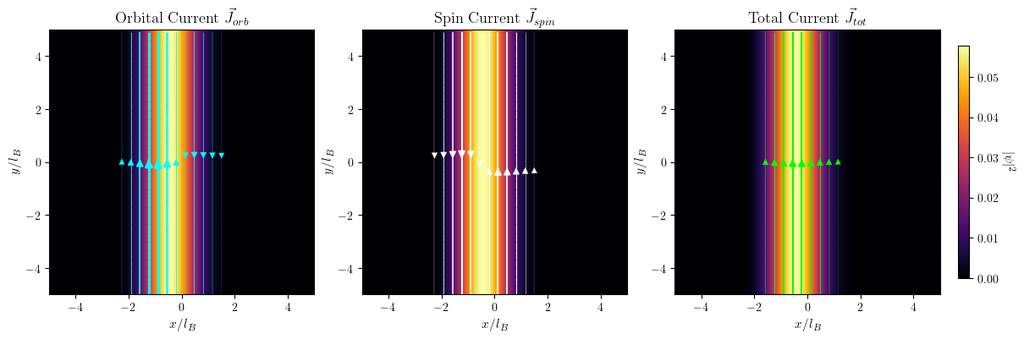

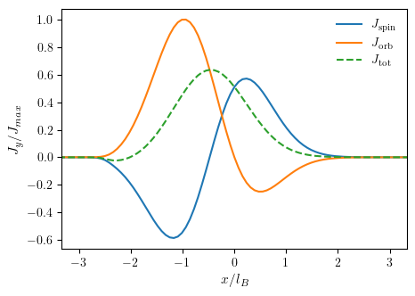

```python
def calculate_currents(psi, A_x, A_y, KX, KY, q=1, hbar=1, m=1):
    psi_k = np.fft.fft2(psi, axes=(1, 2))

    kx_psi = np.fft.ifft2(KX * psi_k, axes=(1, 2))
    ky_psi = np.fft.ifft2(KY * psi_k, axes=(1, 2))

    psi_up, psi_down = psi[0], psi[1]
    psi_up_conj, psi_down_conj = np.conj(psi_up), np.conj(psi_down)

    # Orbital Current Calculation
    J_orb_x = (psi_up_conj*(kx_psi[0] - q*A_x[0]*psi_up) + psi_down_conj*(kx_psi[1] - q*A_x[1]*psi_down)).real / m
    J_orb_y = (psi_up_conj*(ky_psi[0] - q*A_y[0]*psi_up) + psi_down_conj*(ky_psi[1] - q*A_y[1]*psi_down)).real / m

    # Spin Current Calculation (Spin Texture components)
    spin_texture_xy = psi_up_conj * psi_down
    C_x = 2 * spin_texture_xy.real
    C_y = 2 * spin_texture_xy.imag
    C_z = np.abs(psi_up)**2 - np.abs(psi_down)**2

    C_z_k = np.fft.fft2(C_z)

    J_spin_x = (hbar / (2*m)) * np.fft.ifft2(1j * KY * C_z_k).real
    J_spin_y = (hbar / (2*m)) * np.fft.ifft2(-1j * KX * C_z_k).real

    return J_orb_x, J_orb_y, J_spin_x, J_spin_y

J_orb_x, J_orb_y, J_spin_x, J_spin_y = calculate_currents(psi, A_x, A_y, KX, KY)
J_total_x = J_orb_x + J_spin_x
J_total_y = J_orb_y + J_spin_y
J_max = np.max(np.sqrt(J_orb_x**2 + J_orb_y**2))

# --- PLOTTING CURRENTS ---
fig, axes = plt.subplots(1, 3, figsize=(12, 3.8), constrained_layout=True)
density = np.abs(psi[0])**2 + np.abs(psi[1])**2

def plot_stream_panel(ax, Jx, Jy, title, colormap_color):
    im = ax.imshow(density, extent=[-Lx, Lx, -Ly, Ly], origin='lower', cmap='inferno')

    J_mag = np.sqrt(Jx**2 + Jy**2)
    lw = 2.5 * (J_mag / J_max)
    threshold = 0.03 * J_max

    Jx_plot = np.where(J_mag > threshold, Jx, np.nan)
    Jy_plot = np.where(J_mag > threshold, Jy, np.nan)

    ax.streamplot(X, Y, Jx_plot, Jy_plot, color=colormap_color, linewidth=lw, density=1.0, arrowsize=1.2)
    ax.set_title(title)
    ax.set_xlabel(r'$x/l_B$')
    ax.set_ylabel(r'$y/l_B$')
    ax.set_xlim(-Lx, Lx)
    ax.set_ylim(-Ly, Ly)
    return im

plot_stream_panel(axes[0], J_orb_x, J_orb_y, r'Orbital Current $\vec{J}_{orb}$', 'cyan')
plot_stream_panel(axes[1], J_spin_x, J_spin_y, r'Spin Current $\vec{J}_{spin}$', 'white')
im = plot_stream_panel(axes[2], J_total_x, J_total_y, r'Total Current $\vec{J}_{tot}$', 'lime')

cbar = fig.colorbar(im, ax=axes, shrink=0.8, pad=0.02)
cbar.set_label(r'$|\psi|^2$', rotation=270, labelpad=15)
plt.show()

# 1D Cross-section plot
idx_y = N // 2
fig1, ax1d = plt.subplots(figsize=(5, 3.5))
ax1d.plot(x, J_spin_y[idx_y, :] / J_max, label=r"$J_{\mathrm{spin}}$")
ax1d.plot(x, J_orb_y[idx_y, :] / J_max, label=r"$J_{\mathrm{orb}}$")
ax1d.plot(x, J_total_y[idx_y, :] / J_max, label=r"$J_{\mathrm{tot}}$", linestyle='--')
ax1d.set_xlabel(r'$x/l_B$')
ax1d.set_ylabel(r'$J_y / J_{max}$')
ax1d.set_xlim(-Lx/1.5, Lx/1.5)
ax1d.legend(loc="upper right", frameon=False)
plt.show()
```

## 6. Real-Time Dynamics

We now evolve the system in real time using the Schrödinger equation. We employ a 4th-order Runge-Kutta (RK4) method to ensure numerical stability.

$$i\hbar \frac{\partial \psi}{\partial t} = H\psi$$

```python
def compute_time_derivative(psi_state, hbar=1):
    H_gp = calc_gp_potential(psi_state, g) * psi_state

    # FIX 1: Removed 'dx, dy' from the arguments so they don't overwrite 'hbar' and 'm'
    H_kin = kinetic_hamiltonian(psi_state, A_x, A_y, A_t, KX, KY)

    H_sp = spin_hamiltonian(psi_state, B)
    H_trap = potential_well * psi_state

    H_total = H_gp + H_kin + H_sp + H_trap
    return -1j * H_total / hbar

# FIX 2: Sudden change in the electric field to induce motion.
# If the ground state was calculated with E=0.5, setting E=0.0 will make it oscillate.
# For a much stronger kick, you can try E_new = 2.0
E_new = 0.0
A_t[0, :, :] = E_new * X
A_t[1, :, :] = E_new * X

def rk4_step(psi_state, dt):
    """Runge-Kutta 4th order solver step."""
    k1 = compute_time_derivative(psi_state)
    k2 = compute_time_derivative(psi_state + 0.5 * dt * k1)
    k3 = compute_time_derivative(psi_state + 0.5 * dt * k2)
    k4 = compute_time_derivative(psi_state + dt * k3)

    return psi_state + (k1 + 2 * k2 + 2 * k3 + k4) * dt / 6

# FIX 3: Adjusted time parameters for visible dynamics
dt = 0.002            # Larger time steps
max_time_steps = 2000 # Total simulated time = 4.0 (Enough to see movement)
frames = []

def get_total_density(p):
    return np.abs(p[0])**2 + np.abs(p[1])**2

frames.append(get_total_density(psi))
print("Starting real-time evolution...")

for step in range(max_time_steps):
    psi = rk4_step(psi, dt)

    # Save frames more frequently
    if step % 20 == 0:
        frames.append(get_total_density(psi))

print("Evolution complete. Generating animation...")

# Setup Animation
fig_anim, ax_anim = plt.subplots(figsize=(5, 4))
ax_anim.set_xlabel(r'$x / l_B$')
ax_anim.set_ylabel(r'$y / l_B$')
ax_anim.set_title(r'Time Evolution $|\psi|^2$')

# Calculate global maximum so the color scale remains fixed across frames
vmax_global = np.max([np.max(f) for f in frames])

im_anim = ax_anim.imshow(frames[0], cmap='inferno', origin='lower',
                         extent=[-Lx, Lx, -Ly, Ly], vmin=0, vmax=vmax_global)
fig_anim.colorbar(im_anim, ax=ax_anim, label=r'$|\psi|^2$')

def update_frame(frame_idx):
    im_anim.set_data(frames[frame_idx])
    return [im_anim]

ani = animation.FuncAnimation(fig_anim, update_frame, frames=len(frames), blit=True)
plt.close() # Prevent static plot from showing, only the animation below

# To display the animation natively in Jupyter Notebook:
from IPython.display import HTML
HTML(ani.to_jshtml())
```

```
Starting real-time evolution...
Evolution complete. Generating animation...
```

[figure not shown]